# Cálculo de opções - Um experimento de Monte Carlo

Daniel Ryba Zanardini

14/04/2020

## Introdução

O cálculo de opção, através de uma simulação de Monte Carlo, é um método utilizado com muita frequência na matemática financeira, em ambientes com elevadas fontes de incertezas.

Neste projeto, apresentaremos um comparativo entre os resultados obtidos pelo cálculo de opções européias (compra e venda) através de Black-Scholes, além de algumas simulações de Monte Carlo. Também será apresentado um comparativo para o resultado de opções americanas e asiáticas.

## Modelo de Black-Scholes

$$c(X_{t},t) = X_{t}N(d_{1}) - Ke^{-r(T-t)}N(d_{2})\qquad, 0\leq t < T, X_{t}>0$$

$$v(X_{t},t) = Ke^{-r(T-t)}N(-d_{2})-X_{t}N(-d_{1})$$

$$d1 = \dfrac{(ln(\frac{X_{t}}{K})+(r+0,5\sigma^{2})(T-t)}{\sigma\sqrt{T-t}} \qquad\qquad e \qquad \qquad d_{2} = d_{1}-\sigma\sqrt{T-t}$$

Considere que o preço à vista de uma ação seja $X_{0}=1$, com a taxa de juros $r=3$ a.a., o tempo de vencimento da opção seja 1 ano, $\textit{K}=1.1$ e a volatilidade $\sigma=15$ a.a. Temos a solução analítica para o modelo:

|  | CALL | PUTT |
| --- | --- | --- |
|  | $(X\texttt{t} - k)^{+}$ | $(K - X\texttt{t})^{+}$ |
| preço | 0.0338 | 0.1013 |

## Simulação de Monte Carlo

A simulação de Monte Carlo, envolve usar números aleatórios para obter uma amostra com vários caminhos diferentes, que poderiam ser seguidos pelas variáveis subjacentes, em um mundo de risco nulo. Para cada caminho, o resultado é calculado e descontado à taxa de juros livre de risco. A média aritmética do somatório dos resultados descontados é o valor estimado do derivativo.

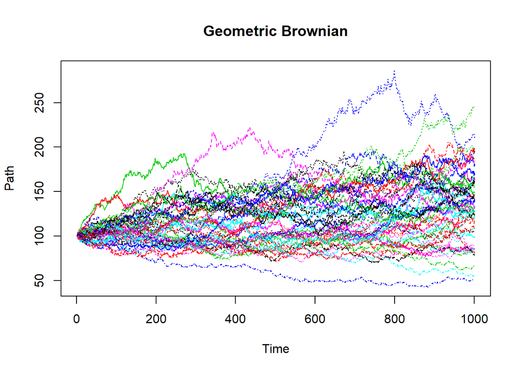

Sejam:

$$c_{t}=E^{Q}[e^{-r\tau}(X_{T}-K)^{+}\mid F_{t}]$$

$$X_{T}=Xe^{(r-0,5\sigma^{2})\tau+\sigma\sqrt{\tau\omega}}$$
onde $\omega \sim N(0,1)$ e $X_{T}$ é a solução da equação diferencial estocástica do processo geométrico browniano escrito sobre a medida martingal equivalente (MME) com volatilidade $\sigma$.

[output not shown]

## Opção Americana

Seja $X_{t}$ um processo estocástico browniano governado por $B_{t}$ com $\sigma$ algebra natural $F_{t}$, Seja $\Theta$ o conjunto de todos os tempos de parada entre t e T e seja $\theta \in \Theta$. Considere $\Lambda(X_{t},t)$ o preço de um derivativo americano em t sobre o ativo subjacente $X_{t}$ tal que t $\in [0,T]$.

$$\Lambda (X_{t},t) = \max_{\theta \in \Theta}{E^{Q}[e^{-r(\theta-t)}\Lambda(X_{\theta},t,\theta)\mid F_{t}]}$$
Um derivativo que possua a possibilidade de exercício antecipado, não possui solução analítica. Sua determinação se dará através de soluções numéricas, como por exemplo, método de Monte Carlo, diferenças finitas, arvores binomiais, dentre outros.

| MC | CALL | t | PUTT |
| --- | --- | --- | --- |
| 100 | - | - | 0.0929 |
| 1000 | - | - | 0.0984 |
| 5000 | - | - | 0.0987 |
| 10000 | - | - | 0.1004 |
| 100000 | - | - | 0.0998 |